# Predicting heart disease using Machine Learning

### Data Dictionary

age - age in years

sex - (1 = male; 0 = female)

cp - chest pain type

0: Typical angina: chest pain related decrease blood supply to the heart

1: Atypical angina: chest pain not related to heart

2: Non-anginal pain: typically esophageal spasms (non heart related)

3: Asymptomatic: chest pain not showing signs of disease

trestbps - resting blood pressure (in mm Hg on admission to the hospital) anything above 130-140 is typically cause for concern

chol - serum cholestoral in mg/dl

serum = LDL + HDL + .2 * triglycerides

above 200 is cause for concern

fbs - (fasting blood sugar > 120 mg/dl) (1 = true; 0 = false)

'>126' mg/dL signals diabetes

restecg - resting electrocardiographic results

0: Nothing to note

1: ST-T Wave abnormality

can range from mild symptoms to severe problems

signals non-normal heart beat

2: Possible or definite left ventricular hypertrophy

Enlarged heart's main pumping chamber

thalach - maximum heart rate achieved

exang - exercise induced angina (1 = yes; 0 = no)

oldpeak - ST depression induced by exercise relative to rest looks at stress of heart during excercise unhealthy heart will

stress more

slope - the slope of the peak exercise ST segment

0: Upsloping: better heart rate with excercise (uncommon)

1: Flatsloping: minimal change (typical healthy heart)

2: Downslopins: signs of unhealthy heart

ca - number of major vessels (0-3) colored by flourosopy

colored vessel means the doctor can see the blood passing through

the more blood movement the better (no clots)

thal - thalium stress result

1,3: normal

6: fixed defect: used to be defect but ok now

7: reversable defect: no proper blood movement when excercising

target - have disease or not (1=yes, 0=no) (= the predicted attribute)

```python
# prepare the tools
import pandas as pd
import numpy as np
import matplotlib.pyplot as plt
%matplotlib inline

import seaborn as sns

from sklearn.linear_model import LogisticRegression
from sklearn.neighbors import KNeighborsClassifier
from sklearn.tree import DecisionTreeClassifier
from sklearn.ensemble import RandomForestClassifier

from sklearn.model_selection import train_test_split, cross_val_score
from sklearn.model_selection import RandomizedSearchCV, GridSearchCV
from sklearn.metrics import confusion_matrix, classification_report, accuracy_score
from sklearn.metrics import precision_score, recall_score, f1_score, plot_roc_curve
```

## Load Data

```python
heart_disease = pd.read_csv("Data/heart-disease.csv")
heart_disease.head()
```

|  | age | sex | cp | trestbps | chol | fbs | restecg | thalach | exang | oldpeak | slope | ca | thal | target |
| --- | --- | --- | --- | --- | --- | --- | --- | --- | --- | --- | --- | --- | --- | --- |
| 0 | 63 | 1 | 3 | 145 | 233 | 1 | 0 | 150 | 0 | 2.3 | 0 | 0 | 1 | 1 |
| 1 | 37 | 1 | 2 | 130 | 250 | 0 | 1 | 187 | 0 | 3.5 | 0 | 0 | 2 | 1 |
| 2 | 41 | 0 | 1 | 130 | 204 | 0 | 0 | 172 | 0 | 1.4 | 2 | 0 | 2 | 1 |
| 3 | 56 | 1 | 1 | 120 | 236 | 0 | 1 | 178 | 0 | 0.8 | 2 | 0 | 2 | 1 |
| 4 | 57 | 0 | 0 | 120 | 354 | 0 | 1 | 163 | 1 | 0.6 | 2 | 0 | 2 | 1 |

## Perform EDA on the Data

- what question(s) are you trying to solve
- what kind of data do we have and how to treat different types
- what's missing from the data and how do we deal with it
- where are the outliers and why should we care about them
- how can you add, change, or remove features from your data?

```python
heart_disease.head()
```

|  | age | sex | cp | trestbps | chol | fbs | restecg | thalach | exang | oldpeak | slope | ca | thal | target |
| --- | --- | --- | --- | --- | --- | --- | --- | --- | --- | --- | --- | --- | --- | --- |
| 0 | 63 | 1 | 3 | 145 | 233 | 1 | 0 | 150 | 0 | 2.3 | 0 | 0 | 1 | 1 |
| 1 | 37 | 1 | 2 | 130 | 250 | 0 | 1 | 187 | 0 | 3.5 | 0 | 0 | 2 | 1 |
| 2 | 41 | 0 | 1 | 130 | 204 | 0 | 0 | 172 | 0 | 1.4 | 2 | 0 | 2 | 1 |
| 3 | 56 | 1 | 1 | 120 | 236 | 0 | 1 | 178 | 0 | 0.8 | 2 | 0 | 2 | 1 |
| 4 | 57 | 0 | 0 | 120 | 354 | 0 | 1 | 163 | 1 | 0.6 | 2 | 0 | 2 | 1 |

```python
heart_disease.tail()
```

|  | age | sex | cp | trestbps | chol | fbs | restecg | thalach | exang | oldpeak | slope | ca | thal | target |
| --- | --- | --- | --- | --- | --- | --- | --- | --- | --- | --- | --- | --- | --- | --- |
| 298 | 57 | 0 | 0 | 140 | 241 | 0 | 1 | 123 | 1 | 0.2 | 1 | 0 | 3 | 0 |
| 299 | 45 | 1 | 3 | 110 | 264 | 0 | 1 | 132 | 0 | 1.2 | 1 | 0 | 3 | 0 |
| 300 | 68 | 1 | 0 | 144 | 193 | 1 | 1 | 141 | 0 | 3.4 | 1 | 2 | 3 | 0 |
| 301 | 57 | 1 | 0 | 130 | 131 | 0 | 1 | 115 | 1 | 1.2 | 1 | 1 | 3 | 0 |
| 302 | 57 | 0 | 1 | 130 | 236 | 0 | 0 | 174 | 0 | 0.0 | 1 | 1 | 2 | 0 |

```python
heart_disease["target"].value_counts()
# the result show that the target values are relatively balanced between the two classes
```

```
1    165
0    138
Name: target, dtype: int64
```

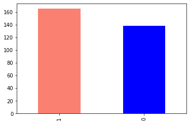

```python
heart_disease["target"].value_counts().plot(kind="bar", color=["salmon", "blue"]);
```

```python
heart_disease.info()
```

```
<class 'pandas.core.frame.DataFrame'>
RangeIndex: 303 entries, 0 to 302
Data columns (total 14 columns):
 #   Column    Non-Null Count  Dtype
---  ------    --------------  -----
 0   age       303 non-null    int64
 1   sex       303 non-null    int64
 2   cp        303 non-null    int64
 3   trestbps  303 non-null    int64
 4   chol      303 non-null    int64
 5   fbs       303 non-null    int64
 6   restecg   303 non-null    int64
 7   thalach   303 non-null    int64
 8   exang     303 non-null    int64
 9   oldpeak   303 non-null    float64
 10  slope     303 non-null    int64
 11  ca        303 non-null    int64
 12  thal      303 non-null    int64
 13  target    303 non-null    int64
dtypes: float64(1), int64(13)
memory usage: 33.3 KB
```

```python
heart_disease.describe()
```

|  | age | sex | cp | trestbps | chol | fbs | restecg | thalach | exang | oldpeak | slope | ca | thal | target |
| --- | --- | --- | --- | --- | --- | --- | --- | --- | --- | --- | --- | --- | --- | --- |
| count | 303.000000 | 303.000000 | 303.000000 | 303.000000 | 303.000000 | 303.000000 | 303.000000 | 303.000000 | 303.000000 | 303.000000 | 303.000000 | 303.000000 | 303.000000 | 303.000000 |
| mean | 54.366337 | 0.683168 | 0.966997 | 131.623762 | 246.264026 | 0.148515 | 0.528053 | 149.646865 | 0.326733 | 1.039604 | 1.399340 | 0.729373 | 2.313531 | 0.544554 |
| std | 9.082101 | 0.466011 | 1.032052 | 17.538143 | 51.830751 | 0.356198 | 0.525860 | 22.905161 | 0.469794 | 1.161075 | 0.616226 | 1.022606 | 0.612277 | 0.498835 |
| min | 29.000000 | 0.000000 | 0.000000 | 94.000000 | 126.000000 | 0.000000 | 0.000000 | 71.000000 | 0.000000 | 0.000000 | 0.000000 | 0.000000 | 0.000000 | 0.000000 |
| 25% | 47.500000 | 0.000000 | 0.000000 | 120.000000 | 211.000000 | 0.000000 | 0.000000 | 133.500000 | 0.000000 | 0.000000 | 1.000000 | 0.000000 | 2.000000 | 0.000000 |
| 50% | 55.000000 | 1.000000 | 1.000000 | 130.000000 | 240.000000 | 0.000000 | 1.000000 | 153.000000 | 0.000000 | 0.800000 | 1.000000 | 0.000000 | 2.000000 | 1.000000 |
| 75% | 61.000000 | 1.000000 | 2.000000 | 140.000000 | 274.500000 | 0.000000 | 1.000000 | 166.000000 | 1.000000 | 1.600000 | 2.000000 | 1.000000 | 3.000000 | 1.000000 |
| max | 77.000000 | 1.000000 | 3.000000 | 200.000000 | 564.000000 | 1.000000 | 2.000000 | 202.000000 | 1.000000 | 6.200000 | 2.000000 | 4.000000 | 3.000000 | 1.000000 |

## Heart Disease frequency according to sex

```python
heart_disease["sex"].value_counts()
```

```
1    207
0     96
Name: sex, dtype: int64
```

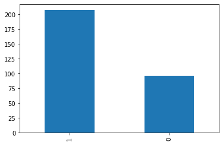

```python
heart_disease["sex"].value_counts().plot(kind="bar");
```

```python
pd.crosstab(heart_disease["target"], heart_disease["sex"])
```

| sex target | 0 | 1 |
| --- | --- | --- |
| 0 | 24 | 114 |
| 1 | 72 | 93 |

```python
114 / np.sum([heart_disease["sex"] == 1]), 24 / np.sum([heart_disease["sex"] == 0])
```

```
(0.5507246376811594, 0.25)
```

```python
(93 / np.sum([heart_disease["sex"] == 1])) * 100, (72 / np.sum([heart_disease["sex"] == 0])) * 100
```

```
(44.927536231884055, 75.0)
```

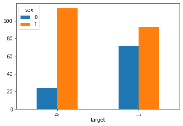

```python
pd.crosstab(heart_disease["target"], heart_disease["sex"]).plot(kind="bar");
```

```python
pd.crosstab(heart_disease["target"], heart_disease["age"] < 30)
```

| age target | False | True |
| --- | --- | --- |
| 0 | 138 | 0 |
| 1 | 164 | 1 |

```python
(heart_disease["age"] == 60).value_counts()
```

```
False    292
True      11
Name: age, dtype: int64
```

```python
heart_disease["age"]
```

```
0      63
1      37
2      41
3      56
4      57
       ..
298    57
299    45
300    68
301    57
302    57
Name: age, Length: 303, dtype: int64
```

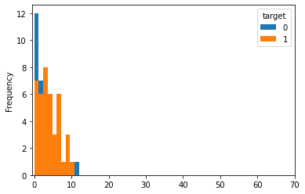

```python
pd.crosstab(heart_disease["age"], heart_disease["target"]).plot(kind="hist")
plt.xticks(np.arange(0, 80, 10));
```

```python
pd.crosstab(heart_disease["target"], heart_disease["age"] < 40), pd.crosstab(heart_disease["target"], heart_disease["age"] < 50), pd.crosstab(heart_disease["target"], heart_disease["age"] < 60), pd.crosstab(heart_disease["target"], heart_disease["age"] < 70), pd.crosstab(heart_disease["target"], heart_disease["age"] < 80)
```

```
(age     False  True
 target
 0         134      4
 1         153     12,
 age     False  True
 target
 0         112     26
 1         103     62,
 age     False  True
 target
 0          52     86
 1          38    127,
 age     False  True
 target
 0           4    134
 1           6    159,
 age     True
 target
 0        138
 1        165)
```

```python
heart_disease["age"].value_counts()
```

```
58    19
57    17
54    16
59    14
52    13
51    12
62    11
44    11
60    11
56    11
64    10
41    10
63     9
67     9
55     8
```

[output cut: 27 more lines]

```python
heart_disease["thalach"].value_counts()
```

```
162    11
160     9
163     9
173     8
152     8
       ..
129     1
128     1
127     1
124     1
71      1
Name: thalach, Length: 91, dtype: int64
```

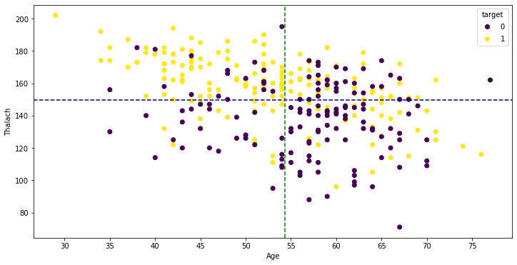

```python
fig, ax = plt.subplots(figsize=(12, 6))
scatter = ax.scatter(heart_disease["age"], heart_disease["thalach"], c=heart_disease["target"]);
ax.legend(*scatter.legend_elements(), title="target");
ax.set(xlabel="Age", ylabel="Thalach");
ax.set_xticks(np.arange(30, 80, 5));
ax.axhline(heart_disease["thalach"].mean(), linestyle="--", c="darkblue");
ax.axvline(heart_disease["age"].mean(), linestyle="--", c="green");
```

```python
pd.crosstab(heart_disease["target"], heart_disease["thalach"] >= 150)
```

| thalach target | False | True |
| --- | --- | --- |
| 0 | 89 | 49 |
| 1 | 43 | 122 |

```python
heart_disease[["thalach", "target"]].corr()
```

|  | thalach | target |
| --- | --- | --- |
| thalach | 1.000000 | 0.421741 |
| target | 0.421741 | 1.000000 |

```python
heart_disease["cp"].value_counts()
```

```
0    143
2     87
1     50
3     23
Name: cp, dtype: int64
```

```python
pd.crosstab(heart_disease["target"], heart_disease["cp"])
```

| cp target | 0 | 1 | 2 | 3 |
| --- | --- | --- | --- | --- |
| 0 | 104 | 9 | 18 | 7 |
| 1 | 39 | 41 | 69 | 16 |

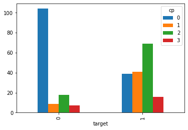

```python
pd.crosstab(heart_disease["target"], heart_disease["cp"]).plot(kind="bar");
```

```python
heart_disease.head()
```

|  | age | sex | cp | trestbps | chol | fbs | restecg | thalach | exang | oldpeak | slope | ca | thal | target |
| --- | --- | --- | --- | --- | --- | --- | --- | --- | --- | --- | --- | --- | --- | --- |
| 0 | 63 | 1 | 3 | 145 | 233 | 1 | 0 | 150 | 0 | 2.3 | 0 | 0 | 1 | 1 |
| 1 | 37 | 1 | 2 | 130 | 250 | 0 | 1 | 187 | 0 | 3.5 | 0 | 0 | 2 | 1 |
| 2 | 41 | 0 | 1 | 130 | 204 | 0 | 0 | 172 | 0 | 1.4 | 2 | 0 | 2 | 1 |
| 3 | 56 | 1 | 1 | 120 | 236 | 0 | 1 | 178 | 0 | 0.8 | 2 | 0 | 2 | 1 |
| 4 | 57 | 0 | 0 | 120 | 354 | 0 | 1 | 163 | 1 | 0.6 | 2 | 0 | 2 | 1 |

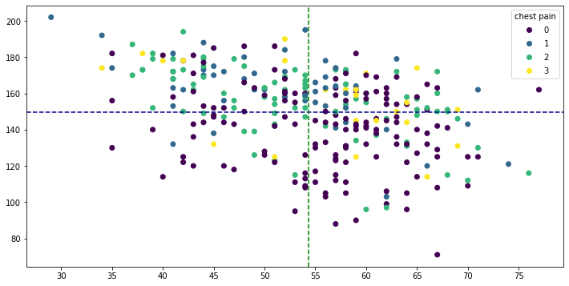

```python
fig, ax = plt.subplots(figsize=(12, 6))
scatter = ax.scatter(x=heart_disease["age"], y=heart_disease["thalach"], c=heart_disease["cp"]);
ax.set_xticks(np.arange(30, 80, 5));
ax.legend(*scatter.legend_elements(), title="chest pain");
ax.axhline(heart_disease["thalach"].mean(), linestyle="--", c="darkblue");
ax.axvline(heart_disease["age"].mean(), linestyle="--", c="green");
```

## Demo Model Try

```python
clf = DecisionTreeClassifier()
X = heart_disease[["age", "thalach", "cp"]]
y = heart_disease["target"]
x_train, x_test, y_train, y_test = train_test_split(X, y, test_size=0.25, random_state=42)
```

```python
clf.fit(x_train, y_train)
```

```
DecisionTreeClassifier()
```

```python
y_preds = clf.predict(x_test)
accuracy_score(y_test, y_preds)
```

```
0.75
```

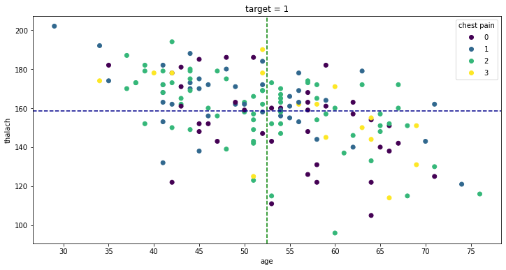

```python
fig, ax = plt.subplots(figsize=(12, 6))
scatter = ax.scatter(x=heart_disease.age[heart_disease.target==1], y=heart_disease.thalach[heart_disease.target==1], c=heart_disease.cp[heart_disease.target==1]);
ax.set_xticks(np.arange(30, 80, 5));
ax.legend(*scatter.legend_elements(), title="chest pain");
ax.axhline(heart_disease.thalach[heart_disease.target==1].mean(), linestyle="--", c="darkblue");
ax.axvline(heart_disease.age[heart_disease.target==1].mean(), linestyle="--", c="green");
ax.set(title="target = 1", xlabel="age", ylabel="thalach");
```

```python
heart_disease.head()
```

|  | age | sex | cp | trestbps | chol | fbs | restecg | thalach | exang | oldpeak | slope | ca | thal | target |
| --- | --- | --- | --- | --- | --- | --- | --- | --- | --- | --- | --- | --- | --- | --- |
| 0 | 63 | 1 | 3 | 145 | 233 | 1 | 0 | 150 | 0 | 2.3 | 0 | 0 | 1 | 1 |
| 1 | 37 | 1 | 2 | 130 | 250 | 0 | 1 | 187 | 0 | 3.5 | 0 | 0 | 2 | 1 |
| 2 | 41 | 0 | 1 | 130 | 204 | 0 | 0 | 172 | 0 | 1.4 | 2 | 0 | 2 | 1 |
| 3 | 56 | 1 | 1 | 120 | 236 | 0 | 1 | 178 | 0 | 0.8 | 2 | 0 | 2 | 1 |
| 4 | 57 | 0 | 0 | 120 | 354 | 0 | 1 | 163 | 1 | 0.6 | 2 | 0 | 2 | 1 |

```python
heart_disease.trestbps[heart_disease.trestbps > 130]
```

```
0      145
5      140
6      140
8      172
9      150
      ...
293    152
295    140
297    164
298    140
300    144
Name: trestbps, Length: 132, dtype: int64
```

```python
pd.crosstab(heart_disease.target, heart_disease.trestbps > 130)
```

| trestbps target | False | True |
| --- | --- | --- |
| 0 | 71 | 67 |
| 1 | 100 | 65 |

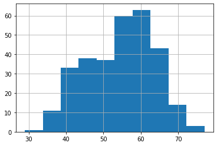

```python
 heart_disease.age.hist();
```

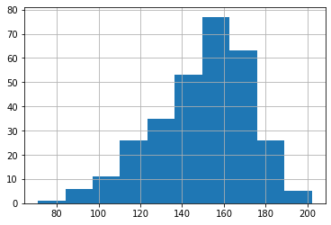

```python
heart_disease.thalach.hist();
```

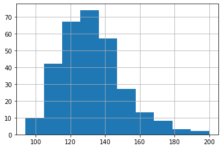

```python
heart_disease.trestbps.hist();
```

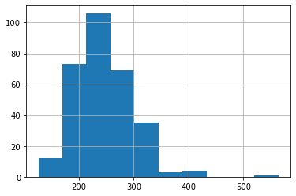

```python
heart_disease.chol.hist();
```

```python
# this is probably an outlier that should be dealt with
heart_disease.chol[heart_disease.chol > 450].value_counts()
```

```
564    1
Name: chol, dtype: int64
```

```python
heart_disease.chol[heart_disease.chol > 400].value_counts()
```

```
407    1
564    1
409    1
417    1
Name: chol, dtype: int64
```

```python
heart_disease.chol[heart_disease.target == 1]
```

```
0      233
1      250
2      204
3      236
4      354
      ...
160    240
161    342
162    157
163    175
164    175
Name: chol, Length: 165, dtype: int64
```

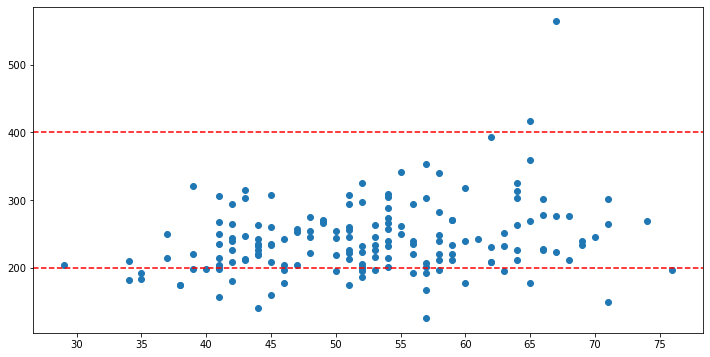

```python
fig, ax = plt.subplots(figsize=(12, 6))
scatter = ax.scatter(x=heart_disease.age[heart_disease.target == 1], y=heart_disease.chol[heart_disease.target == 1]);
ax.set_xticks(np.arange(30, 80, 5))
#ax.legend(*scatter.legend_elements(), title="target");
# written in the data dictionary that a chol level above 200 can cause concern
ax.axhline(y=200, linestyle="--", color="red");
ax.axhline(y=400, linestyle="--", color="red");
```

```python
heart_disease = pd.read_csv("Data/heart-disease.csv")
heart_disease.head()
```

|  | age | sex | cp | trestbps | chol | fbs | restecg | thalach | exang | oldpeak | slope | ca | thal | target |
| --- | --- | --- | --- | --- | --- | --- | --- | --- | --- | --- | --- | --- | --- | --- |
| 0 | 63 | 1 | 3 | 145 | 233 | 1 | 0 | 150 | 0 | 2.3 | 0 | 0 | 1 | 1 |
| 1 | 37 | 1 | 2 | 130 | 250 | 0 | 1 | 187 | 0 | 3.5 | 0 | 0 | 2 | 1 |
| 2 | 41 | 0 | 1 | 130 | 204 | 0 | 0 | 172 | 0 | 1.4 | 2 | 0 | 2 | 1 |
| 3 | 56 | 1 | 1 | 120 | 236 | 0 | 1 | 178 | 0 | 0.8 | 2 | 0 | 2 | 1 |
| 4 | 57 | 0 | 0 | 120 | 354 | 0 | 1 | 163 | 1 | 0.6 | 2 | 0 | 2 | 1 |

```python
heart_disease.fbs.value_counts()
```

```
0    258
1     45
Name: fbs, dtype: int64
```

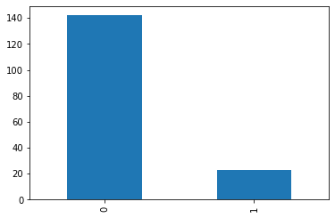

```python
heart_disease.fbs[heart_disease.target==1].value_counts().plot(kind="bar");
```

```python
pd.crosstab(heart_disease.target, heart_disease.fbs)
```

| fbs target | 0 | 1 |
| --- | --- | --- |
| 0 | 116 | 22 |
| 1 | 142 | 23 |

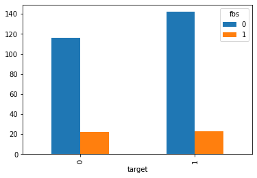

```python
pd.crosstab(heart_disease.target, heart_disease.fbs).plot(kind="bar");
```

```python
heart_disease.head()
```

|  | age | sex | cp | trestbps | chol | fbs | restecg | thalach | exang | oldpeak | slope | ca | thal | target |
| --- | --- | --- | --- | --- | --- | --- | --- | --- | --- | --- | --- | --- | --- | --- |
| 0 | 63 | 1 | 3 | 145 | 233 | 1 | 0 | 150 | 0 | 2.3 | 0 | 0 | 1 | 1 |
| 1 | 37 | 1 | 2 | 130 | 250 | 0 | 1 | 187 | 0 | 3.5 | 0 | 0 | 2 | 1 |
| 2 | 41 | 0 | 1 | 130 | 204 | 0 | 0 | 172 | 0 | 1.4 | 2 | 0 | 2 | 1 |
| 3 | 56 | 1 | 1 | 120 | 236 | 0 | 1 | 178 | 0 | 0.8 | 2 | 0 | 2 | 1 |
| 4 | 57 | 0 | 0 | 120 | 354 | 0 | 1 | 163 | 1 | 0.6 | 2 | 0 | 2 | 1 |

```python
heart_disease.restecg.value_counts()
```

```
1    152
0    147
2      4
Name: restecg, dtype: int64
```

```python
pd.crosstab(heart_disease.restecg, heart_disease.target)
```

| target restecg | 0 | 1 |
| --- | --- | --- |
| 0 | 79 | 68 |
| 1 | 56 | 96 |
| 2 | 3 | 1 |

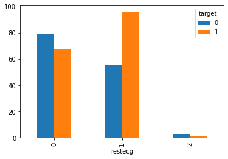

```python
pd.crosstab(heart_disease.restecg, heart_disease.target).plot(kind="bar");
```

```python
heart_disease.exang.value_counts()
```

```
0    204
1     99
Name: exang, dtype: int64
```

```python
pd.crosstab(heart_disease.exang, heart_disease.target)
```

| target exang | 0 | 1 |
| --- | --- | --- |
| 0 | 62 | 142 |
| 1 | 76 | 23 |

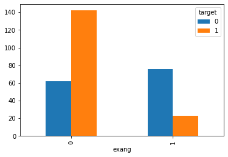

```python
pd.crosstab(heart_disease.exang, heart_disease.target).plot(kind="bar");
```

```python
# correlation matrix
```

```python
heart_disease.corr()
```

|  | age | sex | cp | trestbps | chol | fbs | restecg | thalach | exang | oldpeak | slope | ca | thal | target |
| --- | --- | --- | --- | --- | --- | --- | --- | --- | --- | --- | --- | --- | --- | --- |
| age | 1.000000 | -0.098447 | -0.068653 | 0.279351 | 0.213678 | 0.121308 | -0.116211 | -0.398522 | 0.096801 | 0.210013 | -0.168814 | 0.276326 | 0.068001 | -0.225439 |
| sex | -0.098447 | 1.000000 | -0.049353 | -0.056769 | -0.197912 | 0.045032 | -0.058196 | -0.044020 | 0.141664 | 0.096093 | -0.030711 | 0.118261 | 0.210041 | -0.280937 |
| cp | -0.068653 | -0.049353 | 1.000000 | 0.047608 | -0.076904 | 0.094444 | 0.044421 | 0.295762 | -0.394280 | -0.149230 | 0.119717 | -0.181053 | -0.161736 | 0.433798 |
| trestbps | 0.279351 | -0.056769 | 0.047608 | 1.000000 | 0.123174 | 0.177531 | -0.114103 | -0.046698 | 0.067616 | 0.193216 | -0.121475 | 0.101389 | 0.062210 | -0.144931 |
| chol | 0.213678 | -0.197912 | -0.076904 | 0.123174 | 1.000000 | 0.013294 | -0.151040 | -0.009940 | 0.067023 | 0.053952 | -0.004038 | 0.070511 | 0.098803 | -0.085239 |
| fbs | 0.121308 | 0.045032 | 0.094444 | 0.177531 | 0.013294 | 1.000000 | -0.084189 | -0.008567 | 0.025665 | 0.005747 | -0.059894 | 0.137979 | -0.032019 | -0.028046 |
| restecg | -0.116211 | -0.058196 | 0.044421 | -0.114103 | -0.151040 | -0.084189 | 1.000000 | 0.044123 | -0.070733 | -0.058770 | 0.093045 | -0.072042 | -0.011981 | 0.137230 |
| thalach | -0.398522 | -0.044020 | 0.295762 | -0.046698 | -0.009940 | -0.008567 | 0.044123 | 1.000000 | -0.378812 | -0.344187 | 0.386784 | -0.213177 | -0.096439 | 0.421741 |
| exang | 0.096801 | 0.141664 | -0.394280 | 0.067616 | 0.067023 | 0.025665 | -0.070733 | -0.378812 | 1.000000 | 0.288223 | -0.257748 | 0.115739 | 0.206754 | -0.436757 |
| oldpeak | 0.210013 | 0.096093 | -0.149230 | 0.193216 | 0.053952 | 0.005747 | -0.058770 | -0.344187 | 0.288223 | 1.000000 | -0.577537 | 0.222682 | 0.210244 | -0.430696 |
| slope | -0.168814 | -0.030711 | 0.119717 | -0.121475 | -0.004038 | -0.059894 | 0.093045 | 0.386784 | -0.257748 | -0.577537 | 1.000000 | -0.080155 | -0.104764 | 0.345877 |
| ca | 0.276326 | 0.118261 | -0.181053 | 0.101389 | 0.070511 | 0.137979 | -0.072042 | -0.213177 | 0.115739 | 0.222682 | -0.080155 | 1.000000 | 0.151832 | -0.391724 |
| thal | 0.068001 | 0.210041 | -0.161736 | 0.062210 | 0.098803 | -0.032019 | -0.011981 | -0.096439 | 0.206754 | 0.210244 | -0.104764 | 0.151832 | 1.000000 | -0.344029 |
| target | -0.225439 | -0.280937 | 0.433798 | -0.144931 | -0.085239 | -0.028046 | 0.137230 | 0.421741 | -0.436757 | -0.430696 | 0.345877 | -0.391724 | -0.344029 | 1.000000 |

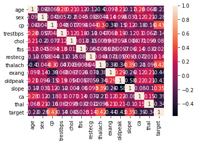

```python
sns.heatmap(heart_disease.corr(), annot=True)
```

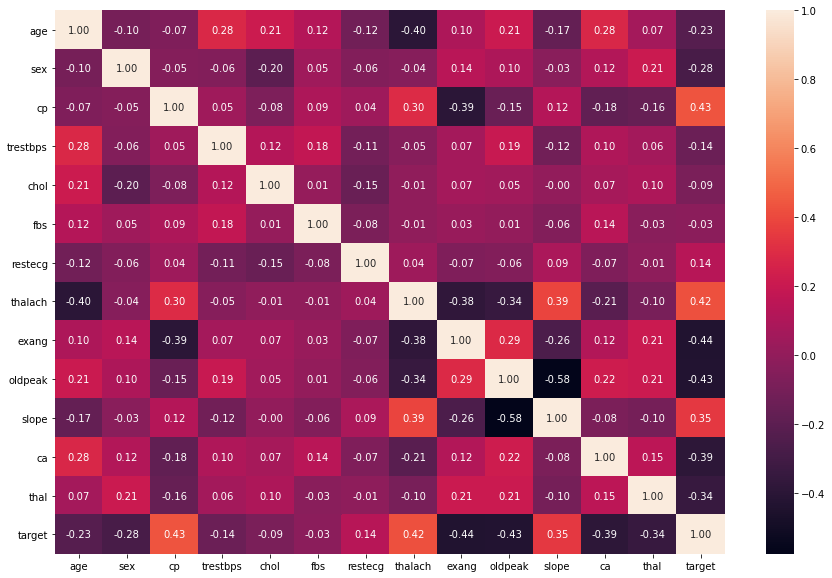

```python
corr_matrix = heart_disease.corr()
fig, ax = plt.subplots(figsize=(15, 10))
ax = sns.heatmap(corr_matrix, annot=True, fmt=".2f");
```

# Modeling

```python
X = heart_disease.drop("target", axis=1)
y = heart_disease.target
```

```python
y.head()
```

```
0    1
1    1
2    1
3    1
4    1
Name: target, dtype: int64
```

```python
X.head()
```

|  | age | sex | cp | trestbps | chol | fbs | restecg | thalach | exang | oldpeak | slope | ca | thal |
| --- | --- | --- | --- | --- | --- | --- | --- | --- | --- | --- | --- | --- | --- |
| 0 | 63 | 1 | 3 | 145 | 233 | 1 | 0 | 150 | 0 | 2.3 | 0 | 0 | 1 |
| 1 | 37 | 1 | 2 | 130 | 250 | 0 | 1 | 187 | 0 | 3.5 | 0 | 0 | 2 |
| 2 | 41 | 0 | 1 | 130 | 204 | 0 | 0 | 172 | 0 | 1.4 | 2 | 0 | 2 |
| 3 | 56 | 1 | 1 | 120 | 236 | 0 | 1 | 178 | 0 | 0.8 | 2 | 0 | 2 |
| 4 | 57 | 0 | 0 | 120 | 354 | 0 | 1 | 163 | 1 | 0.6 | 2 | 0 | 2 |

```python
x_train, x_test, y_train, y_test = train_test_split(X, y, test_size=0.25, random_state=42)
```

```python
x_train
```

|  | age | sex | cp | trestbps | chol | fbs | restecg | thalach | exang | oldpeak | slope | ca | thal |
| --- | --- | --- | --- | --- | --- | --- | --- | --- | --- | --- | --- | --- | --- |
| 287 | 57 | 1 | 1 | 154 | 232 | 0 | 0 | 164 | 0 | 0.0 | 2 | 1 | 2 |
| 282 | 59 | 1 | 2 | 126 | 218 | 1 | 1 | 134 | 0 | 2.2 | 1 | 1 | 1 |
| 197 | 67 | 1 | 0 | 125 | 254 | 1 | 1 | 163 | 0 | 0.2 | 1 | 2 | 3 |
| 158 | 58 | 1 | 1 | 125 | 220 | 0 | 1 | 144 | 0 | 0.4 | 1 | 4 | 3 |
| 164 | 38 | 1 | 2 | 138 | 175 | 0 | 1 | 173 | 0 | 0.0 | 2 | 4 | 2 |
| ... | ... | ... | ... | ... | ... | ... | ... | ... | ... | ... | ... | ... | ... |
| 188 | 50 | 1 | 2 | 140 | 233 | 0 | 1 | 163 | 0 | 0.6 | 1 | 1 | 3 |
| 71 | 51 | 1 | 2 | 94 | 227 | 0 | 1 | 154 | 1 | 0.0 | 2 | 1 | 3 |
| 106 | 69 | 1 | 3 | 160 | 234 | 1 | 0 | 131 | 0 | 0.1 | 1 | 1 | 2 |
| 270 | 46 | 1 | 0 | 120 | 249 | 0 | 0 | 144 | 0 | 0.8 | 2 | 0 | 3 |
| 102 | 63 | 0 | 1 | 140 | 195 | 0 | 1 | 179 | 0 | 0.0 | 2 | 2 | 2 |

227 rows × 13 columns

```python
y_train
```

```
287    0
282    0
197    0
158    1
164    1
      ..
188    0
71     1
106    1
270    0
102    1
Name: target, Length: 227, dtype: int64
```

#### We are going to try four different machine learning models

- Logistic regression
- KNN
- Decision tree
- Random forest tree

```python
models = {"Logistic regression":LogisticRegression(), "KNN":KNeighborsClassifier(), "Decision tree":DecisionTreeClassifier(),
         "Random forest tree":RandomForestClassifier()}
```

```python
def fit_and_score(models, x_train, x_test, y_train, y_test):
    """
    a function to fit data to models and evaluate thier score
    """
    np.random.seed(40)
    model_scores = {}
    for name, model in models.items():
        model.fit(x_train, y_train)
        model_scores[name] = model.score(x_test, y_test)

    return model_scores
```

```python
# the evaluating results of each model
fit_and_score(models, x_train=x_train, x_test=x_test, y_train=y_train, y_test=y_test)
```

```
{'Logistic regression': 0.881578947368421,
 'KNN': 0.6973684210526315,
 'Decision tree': 0.75,
 'Random forest tree': 0.8289473684210527}
```

```python
models_scores = fit_and_score(models, x_train=x_train, x_test=x_test, y_train=y_train, y_test=y_test)
models_scores
```

```
{'Logistic regression': 0.881578947368421,
 'KNN': 0.6973684210526315,
 'Decision tree': 0.75,
 'Random forest tree': 0.8289473684210527}
```

```python
model_compare = pd.DataFrame(models_scores, index=["accuracy"])
model_compare
```

|  | Logistic regression | KNN | Decision tree | Random forest tree |
| --- | --- | --- | --- | --- |
| accuracy | 0.881579 | 0.697368 | 0.75 | 0.828947 |

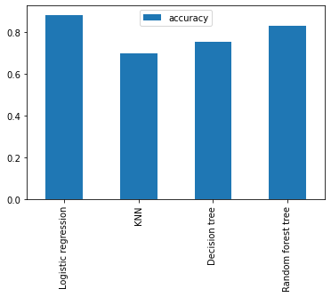

```python
model_compare.T.plot(kind="bar");
```

## Hyperparameter Tuning

```python
# start with KNN
```

```python
train_score = []
test_score = []
```

```python
neighbors = range(1, 21)
```

```python
Knn = KNeighborsClassifier()
```

```python
for i in neighbors:
    Knn.set_params(n_neighbors=i)
    Knn.fit(x_train, y_train)

    train_score.append(Knn.score(x_train, y_train))
    test_score.append(Knn.score(x_test, y_test))
```

```python
train_score
```

```
[1.0,
 0.7929515418502202,
 0.7709251101321586,
 0.7444933920704846,
 0.7577092511013216,
 0.73568281938326,
 0.7268722466960352,
 0.7136563876651982,
 0.7224669603524229,
 0.7136563876651982,
 0.7312775330396476,
 0.7136563876651982,
 0.7092511013215859,
 0.6960352422907489,
 0.6960352422907489,
 0.6784140969162996,
 0.6960352422907489,
 0.6607929515418502,
 0.6916299559471366,
 0.6784140969162996]
```

```python
test_score
```

```
[0.6052631578947368,
 0.6052631578947368,
 0.6710526315789473,
 0.6973684210526315,
 0.6973684210526315,
 0.7105263157894737,
 0.7236842105263158,
 0.7236842105263158,
 0.7105263157894737,
 0.7368421052631579,
 0.75,
 0.7105263157894737,
 0.7105263157894737,
 0.6973684210526315,
 0.6842105263157895,
 0.7236842105263158,
 0.7236842105263158,
 0.7236842105263158,
 0.7368421052631579,
 0.7236842105263158]
```

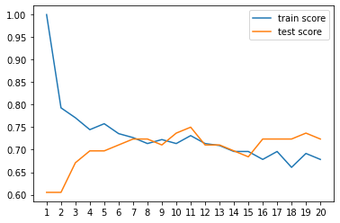

```python
plt.plot(neighbors, train_score, label="train score");
plt.plot(neighbors, test_score, label="test score");
plt.legend();
plt.xticks(np.arange(1, 21, 1));
```

## Hyperparameter Tuning (RandomizedSearchCV)

```python
log_reg_grid = {"C":np.logspace(-4, 4, 20), "solver":["liblinear"]}

rf_grid = {"n_estimators":np.arange(10, 1000, 50), "max_depth":[None,3,  5, 10], "min_samples_split":np.arange(2, 20, 2),
          "min_samples_leaf":np.arange(1, 20, 2)}
```

```python
np.random.seed(42)

rs_log_reg = RandomizedSearchCV(LogisticRegression(),
                               param_distributions=log_reg_grid,
                               cv=5,
                               n_iter=20,
                               verbose=True)

rs_log_reg.fit(x_train, y_train)
```

```
Fitting 5 folds for each of 20 candidates, totalling 100 fits
```

```
RandomizedSearchCV(cv=5, estimator=LogisticRegression(), n_iter=20,
                   param_distributions={'C': array([1.00000000e-04, 2.63665090e-04, 6.95192796e-04, 1.83298071e-03,
       4.83293024e-03, 1.27427499e-02, 3.35981829e-02, 8.85866790e-02,
       2.33572147e-01, 6.15848211e-01, 1.62377674e+00, 4.28133240e+00,
       1.12883789e+01, 2.97635144e+01, 7.84759970e+01, 2.06913808e+02,
       5.45559478e+02, 1.43844989e+03, 3.79269019e+03, 1.00000000e+04]),
                                        'solver': ['liblinear']},
                   verbose=True)
```

```python
rs_log_reg.best_params_
```

```
{'solver': 'liblinear', 'C': 0.23357214690901212}
```

```python
rs_log_reg.score(x_test, y_test)
```

```
0.8947368421052632
```

```python
# Tune the random forest classifier
```

```python
np.random.seed(42)

rs_rf = RandomizedSearchCV(RandomForestClassifier(),
                               param_distributions=rf_grid,
                               cv=5,
                               n_iter=20,
                               verbose=True)

rs_rf.fit(x_train, y_train)
```

```
Fitting 5 folds for each of 20 candidates, totalling 100 fits
```

```
RandomizedSearchCV(cv=5, estimator=RandomForestClassifier(), n_iter=20,
                   param_distributions={'max_depth': [None, 3, 5, 10],
                                        'min_samples_leaf': array([ 1,  3,  5,  7,  9, 11, 13, 15, 17, 19]),
                                        'min_samples_split': array([ 2,  4,  6,  8, 10, 12, 14, 16, 18]),
                                        'n_estimators': array([ 10,  60, 110, 160, 210, 260, 310, 360, 410, 460, 510, 560, 610,
       660, 710, 760, 810, 860, 910, 960])},
                   verbose=True)
```

```python
rs_rf.best_params_
```

```
{'n_estimators': 610,
 'min_samples_split': 4,
 'min_samples_leaf': 15,
 'max_depth': 3}
```

```python
rs_rf.score(x_test, y_test)
```

```
0.8421052631578947
```

## Hyperparameter tuning (GridSearchCV)

```python
log_reg_grid = {"C": np.logspace(-4, 4, 30),
               "solver":["liblinear"]}

gs_log_reg = GridSearchCV(LogisticRegression(),
                         param_grid=log_reg_grid,
                         cv=5,
                         verbose=True)
```

```python
gs_log_reg.fit(x_train, y_train)
```

```
Fitting 5 folds for each of 30 candidates, totalling 150 fits
```

```
GridSearchCV(cv=5, estimator=LogisticRegression(),
             param_grid={'C': array([1.00000000e-04, 1.88739182e-04, 3.56224789e-04, 6.72335754e-04,
       1.26896100e-03, 2.39502662e-03, 4.52035366e-03, 8.53167852e-03,
       1.61026203e-02, 3.03919538e-02, 5.73615251e-02, 1.08263673e-01,
       2.04335972e-01, 3.85662042e-01, 7.27895384e-01, 1.37382380e+00,
       2.59294380e+00, 4.89390092e+00, 9.23670857e+00, 1.74332882e+01,
       3.29034456e+01, 6.21016942e+01, 1.17210230e+02, 2.21221629e+02,
       4.17531894e+02, 7.88046282e+02, 1.48735211e+03, 2.80721620e+03,
       5.29831691e+03, 1.00000000e+04]),
                         'solver': ['liblinear']},
             verbose=True)
```

```python
gs_log_reg.best_params_
```

```
{'C': 0.20433597178569418, 'solver': 'liblinear'}
```

```python
gs_log_reg.score(x_test, y_test)
```

```
0.8947368421052632
```

## Evaluate

```python
y_preds = gs_log_reg.predict(x_test)
y_preds
```

```
array([0, 1, 1, 0, 1, 1, 1, 0, 0, 1, 1, 0, 1, 0, 1, 1, 1, 0, 0, 0, 1, 0,
       0, 1, 1, 1, 1, 1, 0, 1, 0, 0, 0, 0, 1, 0, 1, 1, 1, 1, 1, 1, 1, 1,
       1, 0, 1, 1, 0, 0, 0, 0, 1, 1, 0, 0, 0, 1, 0, 0, 0, 1, 0, 0, 1, 0,
       1, 1, 1, 1, 1, 1, 0, 1, 0, 1], dtype=int64)
```

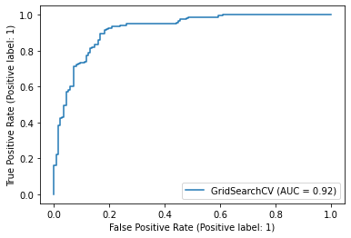

```python
plot_roc_curve(gs_log_reg, X, y);
```

```python
print(confusion_matrix(y_test, y_preds))
```

```
[[30  5]
 [ 3 38]]
```

```python
sns.set(font_scale=1.5)
def plot_conf_mat(y_test, y_preds):
    fig, ax = plt.subplots(figsize=(4, 4))
    ax = sns.heatmap(confusion_matrix(y_test, y_preds), annot=True, cbar=False)

    ax.set(xlabel="true", ylabel="predicted");
```

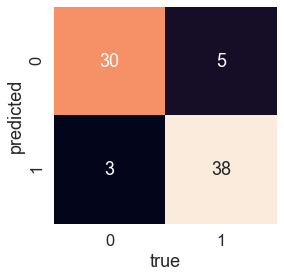

```python
plot_conf_mat(y_test, y_preds);
```

```python
print(classification_report(y_test, y_preds))
```

```
              precision    recall  f1-score   support

           0       0.91      0.86      0.88        35
           1       0.88      0.93      0.90        41

    accuracy                           0.89        76
   macro avg       0.90      0.89      0.89        76
weighted avg       0.90      0.89      0.89        76
```

## Calculate evaluation metrics using cross-validation

```python
gs_log_reg.best_params_
```

```
{'C': 0.20433597178569418, 'solver': 'liblinear'}
```

```python
clf = LogisticRegression(C=0.20433597178569418, solver='liblinear')
```

```python
# cross validation accuracy
cv_accuracy = cross_val_score(clf, X, y, scoring="accuracy")
cv_accuracy
```

```
array([0.81967213, 0.90163934, 0.86885246, 0.88333333, 0.75      ])
```

```python
# cross validation precision
cv_precision = cross_val_score(clf, X, y, scoring="precision")
cv_precision
```

```
array([0.775     , 0.88571429, 0.85714286, 0.86111111, 0.725     ])
```

```python
# cross validation recall
cv_recall = cross_val_score(clf, X, y, scoring="recall")
cv_recall
```

```
array([0.93939394, 0.93939394, 0.90909091, 0.93939394, 0.87878788])
```

```python
# cross validation f1-score
cv_f1 = cross_val_score(clf, X, y, scoring="f1")
cv_f1
```

```
array([0.84931507, 0.91176471, 0.88235294, 0.89855072, 0.79452055])
```

```python
np.mean(cv_accuracy)
```

```
0.8446994535519124
```

```python
np.mean(cv_precision)
```

```
0.8207936507936507
```

```python
np.mean(cv_recall)
```

```
0.9212121212121213
```

```python
np.mean(cv_f1)
```

```
0.8673007976269721
```

```python
metric_score = {"accuray": np.mean(cv_accuracy), "precision": np.mean(cv_precision), "recall": np.mean(cv_recall), "f1": np.mean(cv_f1)}
```

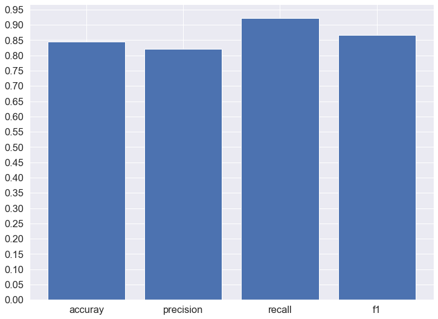

```python
plt.figure(figsize=(12, 9));
plt.bar(metric_score.keys(), metric_score.values());
plt.yticks(np.arange(0, 1, 0.05));
```

```python
clf.fit(x_train, y_train)
```

```
LogisticRegression(C=0.20433597178569418, solver='liblinear')
```

```python
clf.coef_
```

```
array([[ 0.00503922, -0.76947823,  0.68812983, -0.00991718, -0.00127897,
         0.00226276,  0.40721864,  0.02147257, -0.60142004, -0.54531813,
         0.45519223, -0.6569426 , -0.70184842]])
```

```python
feature_dict = dict(zip(heart_disease.columns, list(clf.coef_[0])))
feature_dict
```

```
{'age': 0.005039219028197717,
 'sex': -0.7694782261251526,
 'cp': 0.6881298272584871,
 'trestbps': -0.009917184184719494,
 'chol': -0.0012789704596882492,
 'fbs': 0.002262758498285967,
 'restecg': 0.40721864391970897,
 'thalach': 0.02147257412019282,
 'exang': -0.6014200434372448,
 'oldpeak': -0.5453181276533761,
 'slope': 0.4551922319697744,
 'ca': -0.6569426022962225,
 'thal': -0.7018484174338481}
```

```python
feature_df = pd.DataFrame(feature_dict, index=[0])
feature_df
```

|  | age | sex | cp | trestbps | chol | fbs | restecg | thalach | exang | oldpeak | slope | ca | thal |
| --- | --- | --- | --- | --- | --- | --- | --- | --- | --- | --- | --- | --- | --- |
| 0 | 0.005039 | -0.769478 | 0.68813 | -0.009917 | -0.001279 | 0.002263 | 0.407219 | 0.021473 | -0.60142 | -0.545318 | 0.455192 | -0.656943 | -0.701848 |

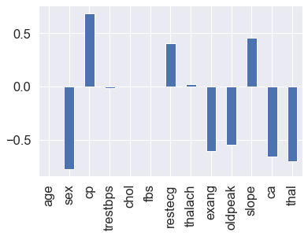

```python
feature_df.T.plot(kind="bar", legend=False);
```

```python
heart_disease_2 = heart_disease.drop(["age", "trestbps", "chol", "fbs", "thalach"], axis=1)
heart_disease_2.head()
```

|  | sex | cp | restecg | exang | oldpeak | slope | ca | thal | target |
| --- | --- | --- | --- | --- | --- | --- | --- | --- | --- |
| 0 | 1 | 3 | 0 | 0 | 2.3 | 0 | 0 | 1 | 1 |
| 1 | 1 | 2 | 1 | 0 | 3.5 | 0 | 0 | 2 | 1 |
| 2 | 0 | 1 | 0 | 0 | 1.4 | 2 | 0 | 2 | 1 |
| 3 | 1 | 1 | 1 | 0 | 0.8 | 2 | 0 | 2 | 1 |
| 4 | 0 | 0 | 1 | 1 | 0.6 | 2 | 0 | 2 | 1 |

```python
X2 = heart_disease_2.drop("target", axis=1)
y2 = heart_disease["target"]
```

```python
x_train2, x_test2, y_train2, y_test2 = train_test_split(X2, y2, test_size=0.25, random_state=42)
```

```python
np.random.seed(42)
clf.fit(x_train2, y_train2)
```

```
LogisticRegression(C=0.20433597178569418, solver='liblinear')
```

```python
y_preds2 = clf.predict(x_test2)
```

```python
accuracy_score(y_test2, y_preds2)
```

```
0.8552631578947368
```